# Lesson4_Arduino_basics

## Lesson 4: Arduino Basics

### Here is the [general Arduino tutorial for ME480](https://alexanderallenbrown.github.io/ME480_FA21_Students/W01E_Implementation_Resources/W01E_Arduino_Resource.html).

### Here is the [Microbike Arduino code](https://github.com/Alexanderallenbrown/drivelab_learning_center/blob/main/Microbike_Arduino_code.zip). you can download the zip file and expand it

### For open the file in Arduino, go File-Open and slect the code that you want to open

[figure not shown]

- the difference between Zumo and Microbike is, Zumo use **Arduino Mega** board; Microbike use **Pololu A-star 32U4**. so you have install pololu A-star 32U4 board. Go Tools-Board-Boards Manager, then search for **Pololu A-Star Boards**,Select the “Pololu A-Star Boards” entry in the list, and click the “Install” button.

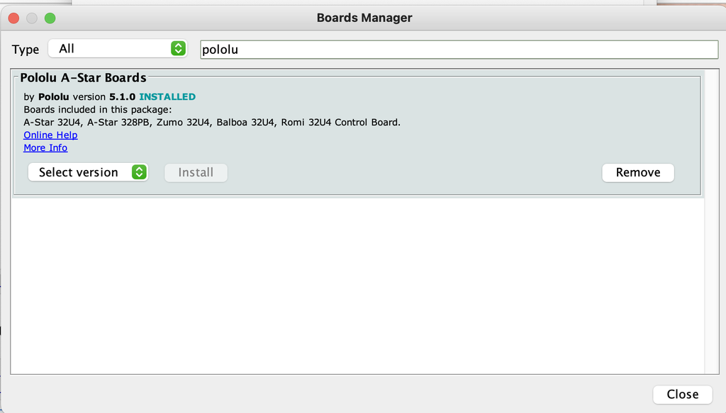

  .After installing, you can choose the board here:

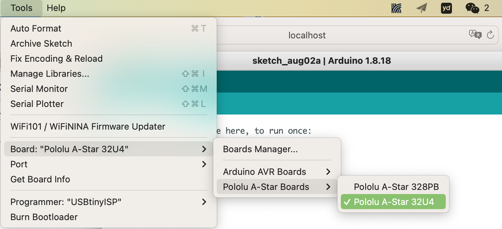

- Make sure you choose the right Port and Board before you install the code
- For Microbike V3 PCB, instead of using USB, you need to use USBtinyISP programmer to upload the code, make sure you choose the right programmer under **Tools**

[figure not shown]

- When upload, select **Upload Using Programmer** under **Sketch**.

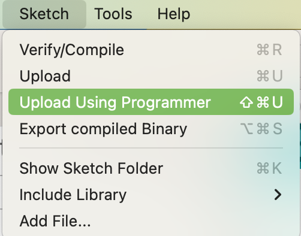

- For collecting data, you need the Bluetooth solder to the Microbike PCB board and connect Bluetooth to your computer. And read data from Serial Monitor(make sure select the right Buad rate).